# Data Programming Project 2024

Author

Lucas Lorenzo Jakin, 89211034

# Predicting Secondary School Student Performance (EDA)

## Student Performance Dataset

Education is a key factor for achieving a long-term economic progress. During the last decades, the portuguese educational level has improved. However, the statistics keep Portugal at Europe’s tail end due to its *high student failure* and *dropping rates*.

In particular, failure in the core classes of Mathematics and Portuguese (native language) is extremely serious, since they provide fundamental knowledge for the success in other remaining subjects.

The **chosen dataset** (Cortez (2014)) contains real-world data from two Portuguese secondary schools. Data was collected using two sources: mark reports, and questionnaires.

```r
library(tidyverse)
library(dplyr)
library(skimr)
library(ggcorrplot)
library(gt)
library(ggplot2)
dataset <- read.csv("student_data.csv", header = T)
nrow(dataset)
```

```
[1] 395
```

Now about the dataframe; The initial version contained scarce information (only the grades and number of absences were available), it was complemented with the latter, which allowed the collection of several demographic, social and school related attributes. The final dataframe consists of 33 columns (attributes), where G3 represents the target variable, the one that we want to predict.

The dataset looks like the following:

```r
  head(dataset)
```

```
  school sex age address famsize Pstatus Medu Fedu     Mjob     Fjob     reason
1     GP   F  18       U     GT3       A    4    4  at_home  teacher     course
2     GP   F  17       U     GT3       T    1    1  at_home    other     course
3     GP   F  15       U     LE3       T    1    1  at_home    other      other
4     GP   F  15       U     GT3       T    4    2   health services       home
5     GP   F  16       U     GT3       T    3    3    other    other       home
6     GP   M  16       U     LE3       T    4    3 services    other reputation
  guardian traveltime studytime failures schoolsup famsup paid activities
1   mother          2         2        0       yes     no   no         no
2   father          1         2        0        no    yes   no         no
3   mother          1         2        3       yes     no  yes         no
4   mother          1         3        0        no    yes  yes        yes
5   father          1         2        0        no    yes  yes         no
6   mother          1         2        0        no    yes  yes        yes
  nursery higher internet romantic famrel freetime goout Dalc Walc health
1     yes    yes       no       no      4        3     4    1    1      3
2      no    yes      yes       no      5        3     3    1    1      3
3     yes    yes      yes       no      4        3     2    2    3      3
4     yes    yes      yes      yes      3        2     2    1    1      5
5     yes    yes       no       no      4        3     2    1    2      5
6     yes    yes      yes       no      5        4     2    1    2      5
  absences G1 G2 G3
1        6  5  6  6
2        4  5  5  6
3       10  7  8 10
4        2 15 14 15
5        4  6 10 10
6       10 15 15 15
```

# Attributes & their descriptions

> Data Distribution

```r
  skim(dataset)
```

Data summary

| Name | dataset |
| --- | --- |
| Number of rows | 395 |
| Number of columns | 33 |
| _______________________ |  |
| Column type frequency: |  |
| character | 17 |
| numeric | 16 |
| ________________________ |  |
| Group variables | None |

**Variable type: character**

| skim_variable | n_missing | complete_rate | min | max | empty | n_unique | whitespace |
| --- | --- | --- | --- | --- | --- | --- | --- |
| school | 0 | 1 | 2 | 2 | 0 | 2 | 0 |
| sex | 0 | 1 | 1 | 1 | 0 | 2 | 0 |
| address | 0 | 1 | 1 | 1 | 0 | 2 | 0 |
| famsize | 0 | 1 | 3 | 3 | 0 | 2 | 0 |
| Pstatus | 0 | 1 | 1 | 1 | 0 | 2 | 0 |
| Mjob | 0 | 1 | 5 | 8 | 0 | 5 | 0 |
| Fjob | 0 | 1 | 5 | 8 | 0 | 5 | 0 |
| reason | 0 | 1 | 4 | 10 | 0 | 4 | 0 |
| guardian | 0 | 1 | 5 | 6 | 0 | 3 | 0 |
| schoolsup | 0 | 1 | 2 | 3 | 0 | 2 | 0 |
| famsup | 0 | 1 | 2 | 3 | 0 | 2 | 0 |
| paid | 0 | 1 | 2 | 3 | 0 | 2 | 0 |
| activities | 0 | 1 | 2 | 3 | 0 | 2 | 0 |
| nursery | 0 | 1 | 2 | 3 | 0 | 2 | 0 |
| higher | 0 | 1 | 2 | 3 | 0 | 2 | 0 |
| internet | 0 | 1 | 2 | 3 | 0 | 2 | 0 |
| romantic | 0 | 1 | 2 | 3 | 0 | 2 | 0 |

**Variable type: numeric**

| skim_variable | n_missing | complete_rate | mean | sd | p0 | p25 | p50 | p75 | p100 | hist |
| --- | --- | --- | --- | --- | --- | --- | --- | --- | --- | --- |
| age | 0 | 1 | 16.70 | 1.28 | 15 | 16 | 17 | 18 | 22 | ▇▅▅▁▁ |
| Medu | 0 | 1 | 2.75 | 1.09 | 0 | 2 | 3 | 4 | 4 | ▁▃▆▆▇ |
| Fedu | 0 | 1 | 2.52 | 1.09 | 0 | 2 | 2 | 3 | 4 | ▁▆▇▇▇ |
| traveltime | 0 | 1 | 1.45 | 0.70 | 1 | 1 | 1 | 2 | 4 | ▇▃▁▁▁ |
| studytime | 0 | 1 | 2.04 | 0.84 | 1 | 1 | 2 | 2 | 4 | ▅▇▁▂▁ |
| failures | 0 | 1 | 0.33 | 0.74 | 0 | 0 | 0 | 0 | 3 | ▇▁▁▁▁ |
| famrel | 0 | 1 | 3.94 | 0.90 | 1 | 4 | 4 | 5 | 5 | ▁▁▃▇▅ |
| freetime | 0 | 1 | 3.24 | 1.00 | 1 | 3 | 3 | 4 | 5 | ▁▃▇▆▂ |
| goout | 0 | 1 | 3.11 | 1.11 | 1 | 2 | 3 | 4 | 5 | ▂▆▇▅▃ |
| Dalc | 0 | 1 | 1.48 | 0.89 | 1 | 1 | 1 | 2 | 5 | ▇▂▁▁▁ |
| Walc | 0 | 1 | 2.29 | 1.29 | 1 | 1 | 2 | 3 | 5 | ▇▅▅▃▂ |
| health | 0 | 1 | 3.55 | 1.39 | 1 | 3 | 4 | 5 | 5 | ▂▂▅▃▇ |
| absences | 0 | 1 | 5.71 | 8.00 | 0 | 0 | 4 | 8 | 75 | ▇▁▁▁▁ |
| G1 | 0 | 1 | 10.91 | 3.32 | 3 | 8 | 11 | 13 | 19 | ▂▇▇▆▂ |
| G2 | 0 | 1 | 10.71 | 3.76 | 0 | 9 | 11 | 13 | 19 | ▁▂▇▆▂ |
| G3 | 0 | 1 | 10.42 | 4.58 | 0 | 8 | 11 | 14 | 20 | ▂▃▇▅▁ |

- In this analysis I used the **skim()** function that provides a neat summary of the dataset, revealing key statistics and characteristics of the data. The dataframe is “partitioned” into two distinct data types: **Numerical** and **String**.
- Numerical attributes were examined for statistical measures(mean,median,standard deviation) and gave a description on how are the attributes distributed.
- The dataframe does not contain any missing values, which is crucial for the modeling(algorithm) part and making predictions.

```r
library(knitr)
att <- colnames(dataset)
description <- c("student's school(binary)","student's sex(binary)" ,"student's age(Num)","home address","family size(binary)" ,"parent's cohabition status(binary)","mother's education(Num)","father's education(Num)","mother's job(nominal)","father's job(nominal)","reason to choose school(nominal)","student's guardian(nominal)","travel time (Num)","weekly study time(Num)","past class failures(Num)","extra school support(binary)","family educational support(binary)","extra paid classes(binary)","extra-curricular activities(binary)","attended nursery school(binary)","wants to take higher education(binary)","internet access(binary)","romantic relationship(binary)","quality of family relationship(Num)","free time(Num)","going out w/ friends(Num)","workday alcohol consumption(Num)","weekend alcohol consumption(Num)","health status(Num)","absences (Num)","first period grade(Num)","second period grade(Num)","final grade(Num)")

table<- data.frame(Attribute = att, Description = description)
```

Table 1 listed below shows all the columns that are present inside the data frame combined with their descriptions and data type.

```r
  table %>% gt()
```

Table 1: The preprocessed student related variables

| Attribute | Description |
| --- | --- |
| school | student's school(binary) |
| sex | student's sex(binary) |
| age | student's age(Num) |
| address | home address |
| famsize | family size(binary) |
| Pstatus | parent's cohabition status(binary) |
| Medu | mother's education(Num) |
| Fedu | father's education(Num) |
| Mjob | mother's job(nominal) |
| Fjob | father's job(nominal) |
| reason | reason to choose school(nominal) |
| guardian | student's guardian(nominal) |
| traveltime | travel time (Num) |
| studytime | weekly study time(Num) |
| failures | past class failures(Num) |
| schoolsup | extra school support(binary) |
| famsup | family educational support(binary) |
| paid | extra paid classes(binary) |
| activities | extra-curricular activities(binary) |
| nursery | attended nursery school(binary) |
| higher | wants to take higher education(binary) |
| internet | internet access(binary) |
| romantic | romantic relationship(binary) |
| famrel | quality of family relationship(Num) |
| freetime | free time(Num) |
| goout | going out w/ friends(Num) |
| Dalc | workday alcohol consumption(Num) |
| Walc | weekend alcohol consumption(Num) |
| health | health status(Num) |
| absences | absences (Num) |
| G1 | first period grade(Num) |
| G2 | second period grade(Num) |
| G3 | final grade(Num) |

## String Data Distributions

> SCHOOL

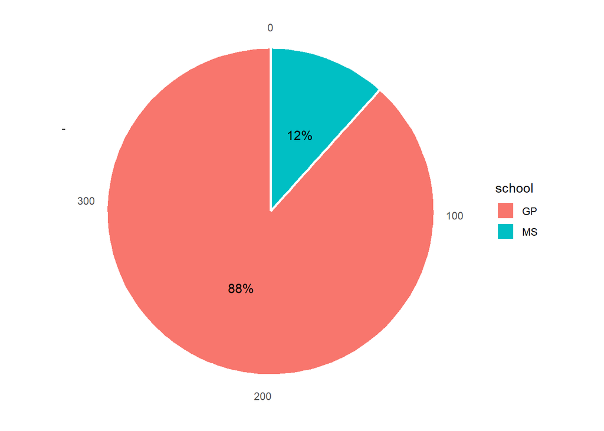

```r
dataset %>% select(school) %>%
  count(school) %>%
  ggplot(., aes(x="", n, fill = school)) +
  geom_bar(width = 1, size = 1, color = "white",stat = "identity") + coord_polar("y", start = 0) +
  geom_text(aes(label = paste0(round((n/395)*100),"%")),
            position = position_stack(vjust = 0.5)) +
  theme_classic() +
  labs(x = NULL, y = NULL) +
  theme(axis.line = element_blank())
```

> SEX

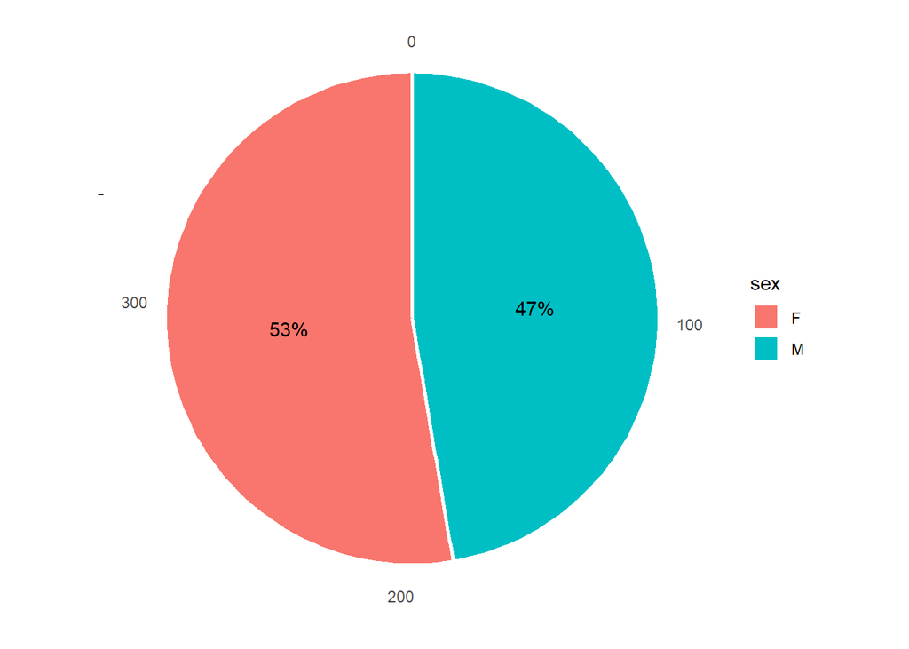

```r
dataset %>% select(sex) %>%
  count(sex) %>%
  ggplot(., aes(x="", n, fill = sex)) +
  geom_bar(width = 1, size = 1, color = "white",stat = "identity") + coord_polar("y", start = 0) +
  geom_text(aes(label = paste0(round((n/395)*100),"%")),
            position = position_stack(vjust = 0.5)) +
  theme_classic() +
  labs(x = NULL, y = NULL) +
  theme(axis.line = element_blank())
```

> ADDRESS

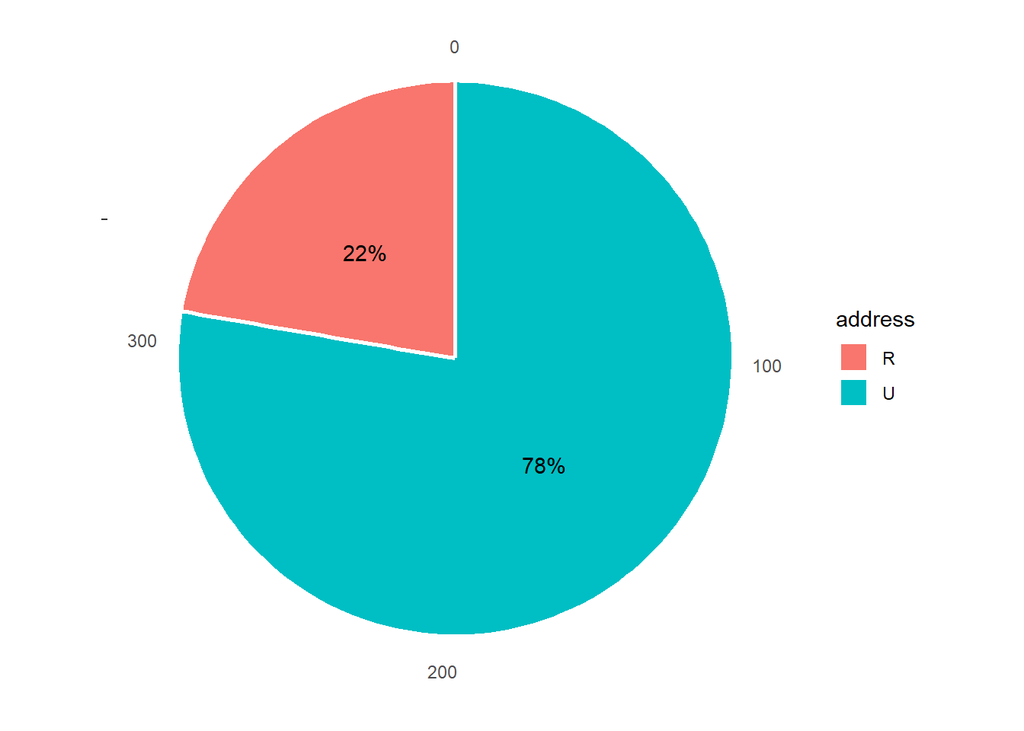

```r
dataset %>% select(address) %>%
  count(address) %>%
  ggplot(., aes(x="", n, fill = address)) +
  geom_bar(width = 1, size = 1, color = "white",stat = "identity") + coord_polar("y", start = 0) +
  geom_text(aes(label = paste0(round((n/395)*100),"%")),
            position = position_stack(vjust = 0.5)) +
  theme_classic() +
  labs(x = NULL, y = NULL) +
  theme(axis.line = element_blank())
```

> FAMSIZE

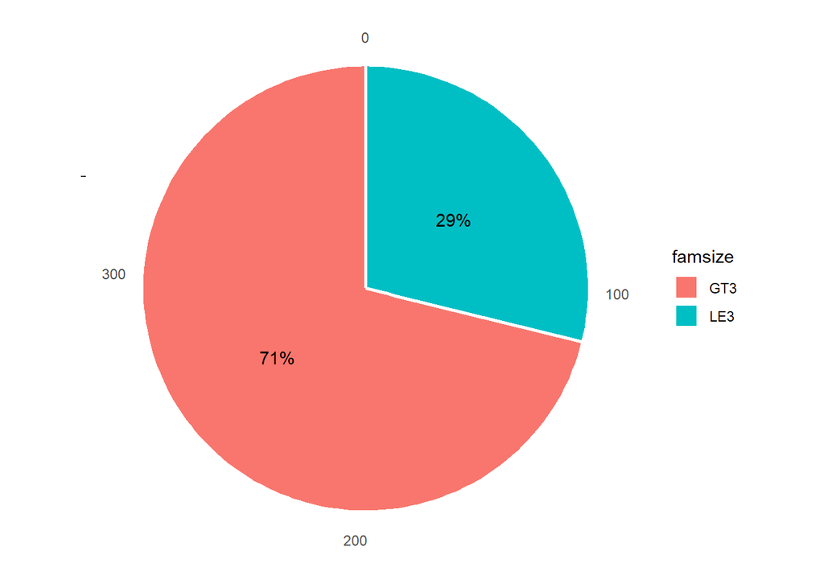

```r
dataset %>% select(famsize) %>%
  count(famsize) %>%
  ggplot(., aes(x="", n, fill = famsize)) +
  geom_bar(width = 1, size = 1, color = "white",stat = "identity") + coord_polar("y", start = 0) +
  geom_text(aes(label = paste0(round((n/395)*100),"%")),
            position = position_stack(vjust = 0.5)) +
  theme_classic() +
  labs(x = NULL, y = NULL) +
  theme(axis.line = element_blank())
```

> PSTATUS

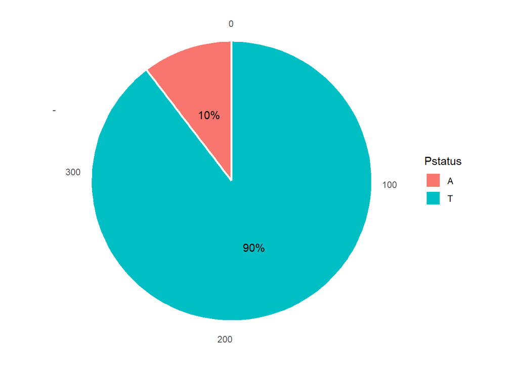

```r
dataset %>% select(Pstatus) %>%
  count(Pstatus) %>%
  ggplot(., aes(x="", n, fill = Pstatus)) +
  geom_bar(width = 1, size = 1, color = "white",stat = "identity") + coord_polar("y", start = 0) +
  geom_text(aes(label = paste0(round((n/395)*100),"%")),
            position = position_stack(vjust = 0.5)) +
  theme_classic() +
  labs(x = NULL, y = NULL) +
  theme(axis.line = element_blank())
```

> MJOB

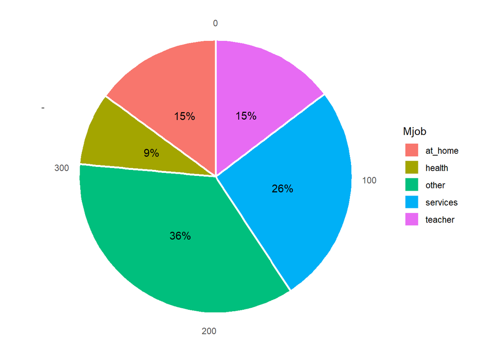

```r
dataset %>% select(Mjob) %>%
  count(Mjob) %>%
  ggplot(., aes(x="", n, fill = Mjob)) +
  geom_bar(width = 1, size = 1, color = "white",stat = "identity") + coord_polar("y", start = 0) +
  geom_text(aes(label = paste0(round((n/395)*100),"%")),
            position = position_stack(vjust = 0.5)) +
  theme_classic() +
  labs(x = NULL, y = NULL) +
  theme(axis.line = element_blank())
```

> FJOB

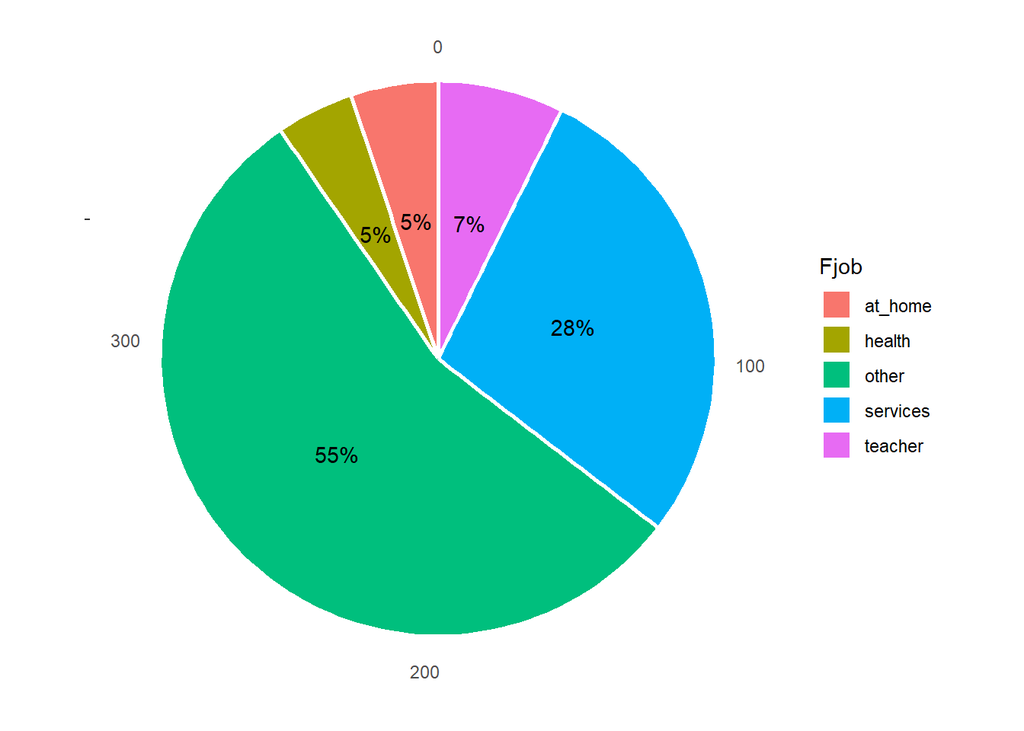

```r
dataset %>% select(Fjob) %>%
  count(Fjob) %>%
  ggplot(., aes(x="", n, fill = Fjob)) +
  geom_bar(width = 1, size = 1, color = "white",stat = "identity") + coord_polar("y", start = 0) +
  geom_text(aes(label = paste0(round((n/395)*100),"%")),
            position = position_stack(vjust = 0.5)) +
  theme_classic() +
  labs(x = NULL, y = NULL) +
  theme(axis.line = element_blank())
```

> REASON

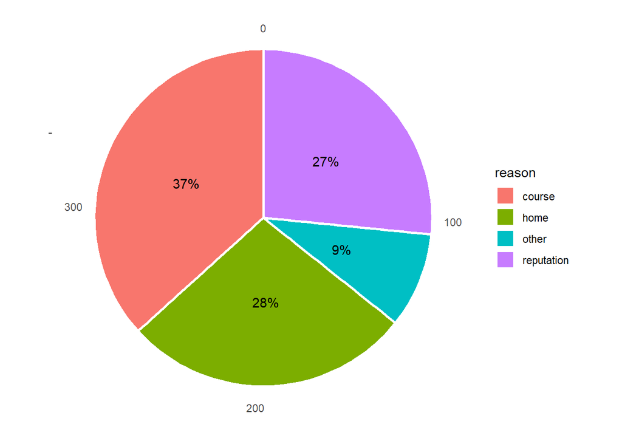

```r
dataset %>% select(reason) %>%
  count(reason) %>%
  ggplot(., aes(x="", n, fill = reason)) +
  geom_bar(width = 1, size = 1, color = "white",stat = "identity") + coord_polar("y", start = 0) +
  geom_text(aes(label = paste0(round((n/395)*100),"%")),
            position = position_stack(vjust = 0.5)) +
  theme_classic() +
  labs(x = NULL, y = NULL) +
  theme(axis.line = element_blank())
```

> GUARDIAN

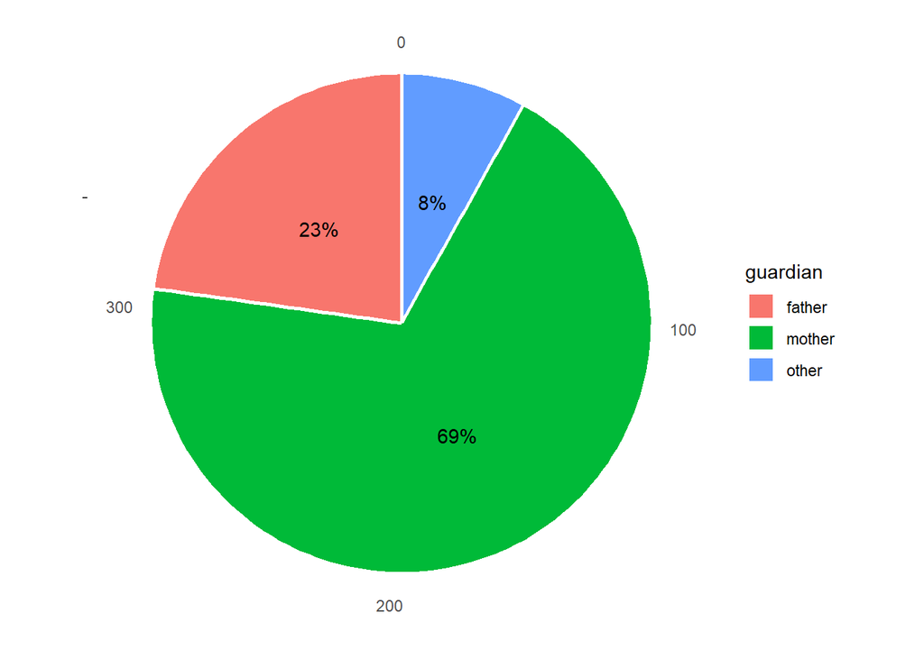

```r
dataset %>% select(guardian) %>%
  count(guardian) %>%
  ggplot(., aes(x="", n, fill = guardian)) +
  geom_bar(width = 1, size = 1, color = "white",stat = "identity") + coord_polar("y", start = 0) +
  geom_text(aes(label = paste0(round((n/395)*100),"%")),
            position = position_stack(vjust = 0.5)) +
  theme_classic() +
  labs(x = NULL, y = NULL) +
  theme(axis.line = element_blank())
```

> SCHOOLSUP

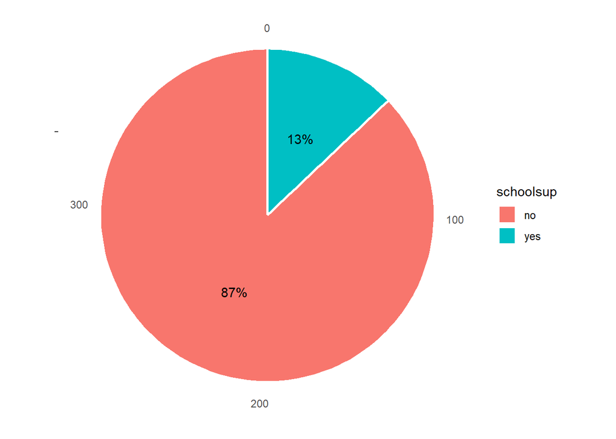

```r
dataset %>% select(schoolsup) %>%
  count(schoolsup) %>%
  ggplot(., aes(x="", n, fill = schoolsup)) +
  geom_bar(width = 1, size = 1, color = "white",stat = "identity") + coord_polar("y", start = 0) +
  geom_text(aes(label = paste0(round((n/395)*100),"%")),
            position = position_stack(vjust = 0.5)) +
  theme_classic() +
  labs(x = NULL, y = NULL) +
  theme(axis.line = element_blank())
```

> FAMSUP

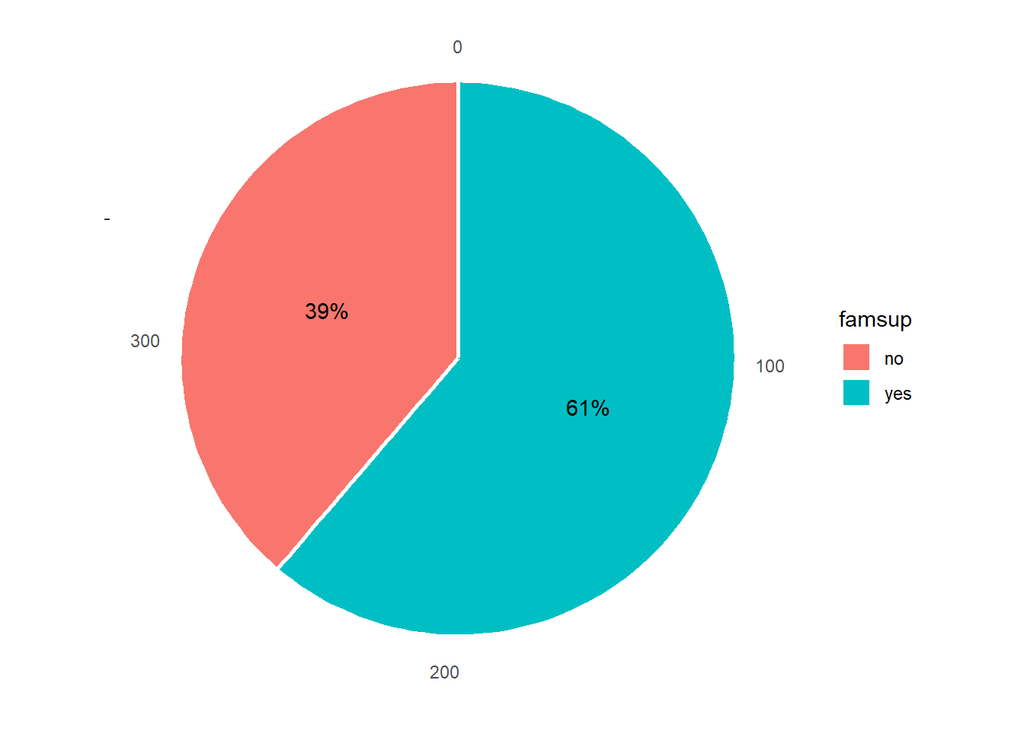

```r
dataset %>% select(famsup) %>%
  count(famsup) %>%
  ggplot(., aes(x="", n, fill = famsup)) +
  geom_bar(width = 1, size = 1, color = "white",stat = "identity") + coord_polar("y", start = 0) +
  geom_text(aes(label = paste0(round((n/395)*100),"%")),
            position = position_stack(vjust = 0.5)) +
  theme_classic() +
  labs(x = NULL, y = NULL) +
  theme(axis.line = element_blank())
```

> PAID

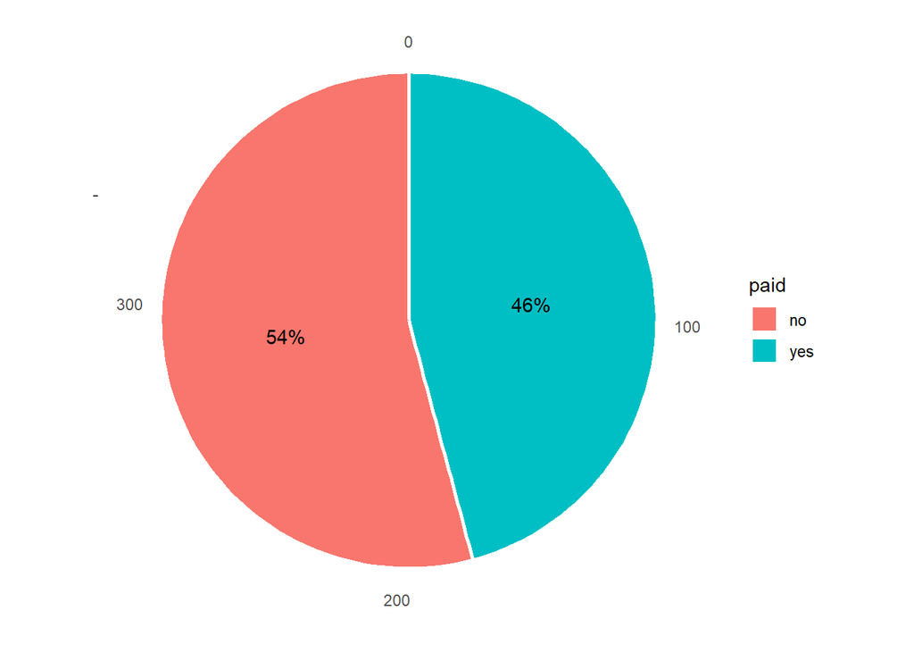

```r
dataset %>% select(paid) %>%
  count(paid) %>%
  ggplot(., aes(x="", n, fill = paid)) +
  geom_bar(width = 1, size = 1, color = "white",stat = "identity") + coord_polar("y", start = 0) +
  geom_text(aes(label = paste0(round((n/395)*100),"%")),
            position = position_stack(vjust = 0.5)) +
  theme_classic() +
  labs(x = NULL, y = NULL) +
  theme(axis.line = element_blank())
```

> ACTIVITIES

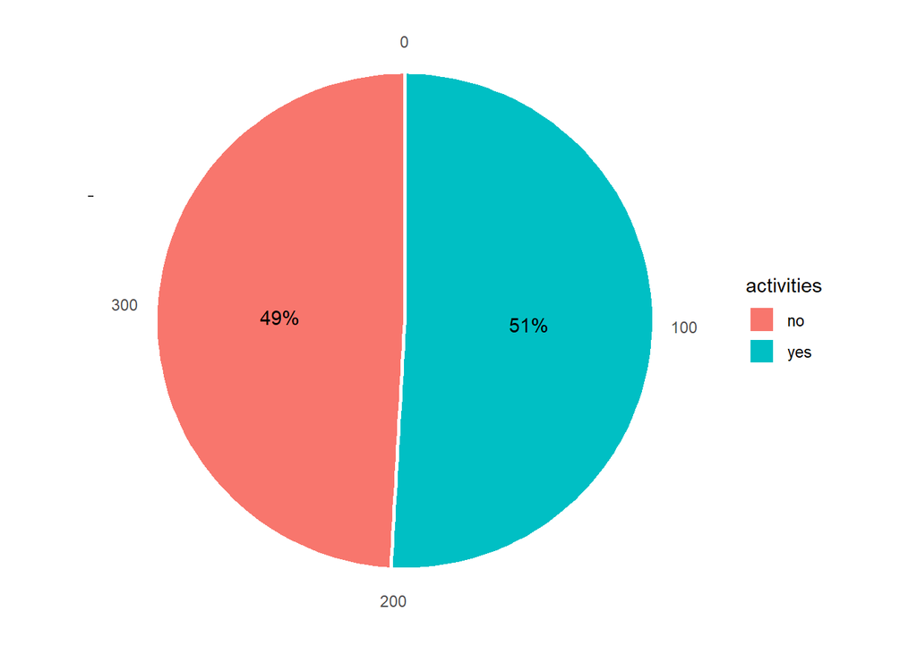

```r
dataset %>% select(activities) %>%
  count(activities) %>%
  ggplot(., aes(x="", n, fill = activities)) +
  geom_bar(width = 1, size = 1, color = "white",stat = "identity") + coord_polar("y", start = 0) +
  geom_text(aes(label = paste0(round((n/395)*100),"%")),
            position = position_stack(vjust = 0.5)) +
  theme_classic() +
  labs(x = NULL, y = NULL) +
  theme(axis.line = element_blank())
```

> NURSERY

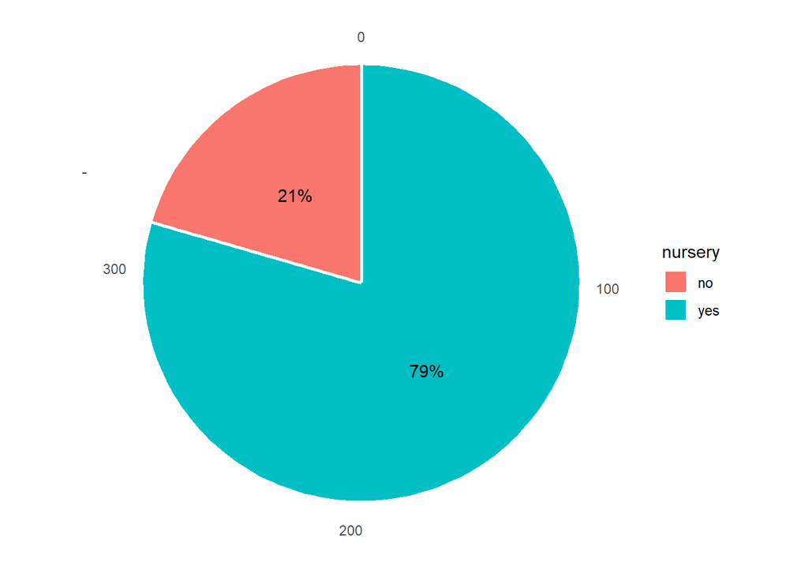

```r
dataset %>% select(nursery) %>%
  count(nursery) %>%
  ggplot(., aes(x="", n, fill = nursery)) +
  geom_bar(width = 1, size = 1, color = "white",stat = "identity") + coord_polar("y", start = 0) +
  geom_text(aes(label = paste0(round((n/395)*100),"%")),
            position = position_stack(vjust = 0.5)) +
  theme_classic() +
  labs(x = NULL, y = NULL) +
  theme(axis.line = element_blank())
```

> HIGHER

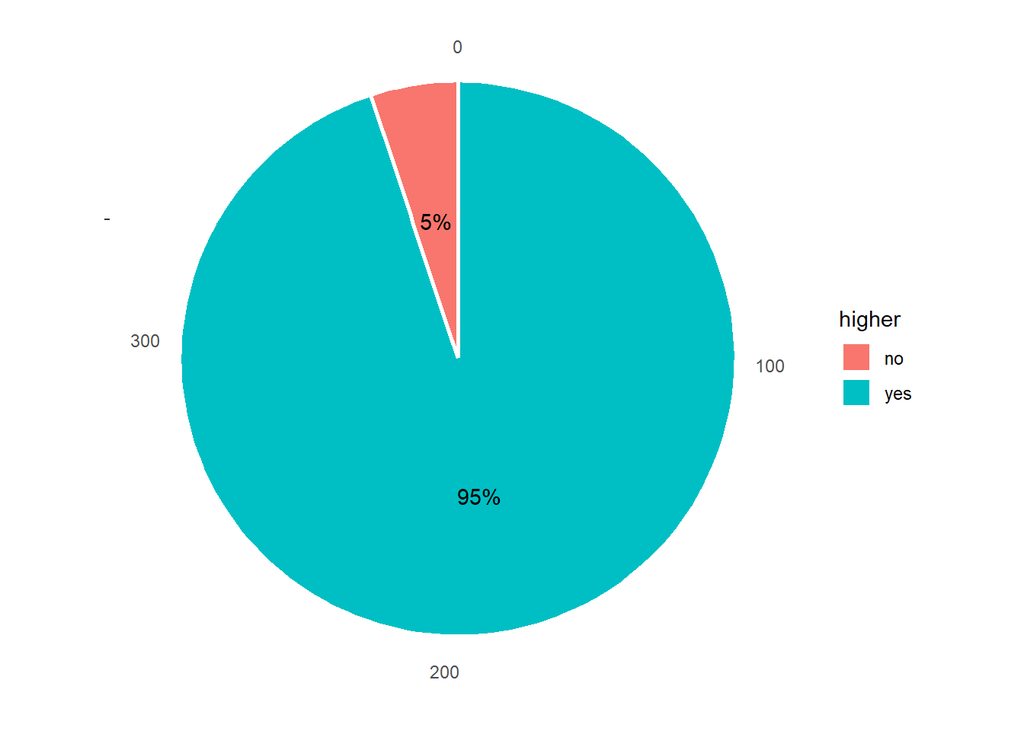

```r
dataset %>% select(higher) %>%
  count(higher) %>%
  ggplot(., aes(x="", n, fill = higher)) +
  geom_bar(width = 1, size = 1, color = "white",stat = "identity") + coord_polar("y", start = 0) +
  geom_text(aes(label = paste0(round((n/395)*100),"%")),
            position = position_stack(vjust = 0.5)) +
  theme_classic() +
  labs(x = NULL, y = NULL) +
  theme(axis.line = element_blank())
```

> INTERNET

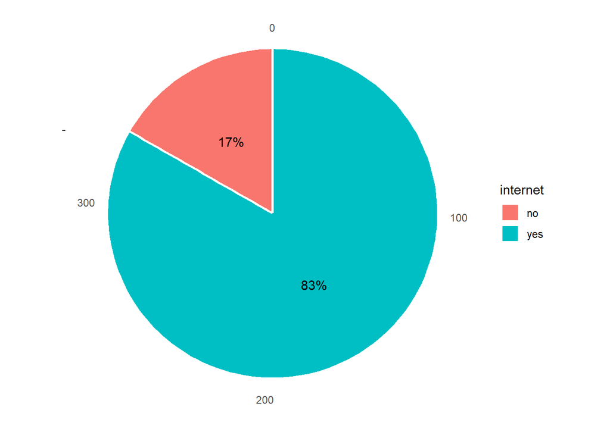

```r
dataset %>% select(internet) %>%
  count(internet) %>%
  ggplot(., aes(x="", n, fill = internet)) +
  geom_bar(width = 1, size = 1, color = "white",stat = "identity") + coord_polar("y", start = 0) +
  geom_text(aes(label = paste0(round((n/395)*100),"%")),
            position = position_stack(vjust = 0.5)) +
  theme_classic() +
  labs(x = NULL, y = NULL) +
  theme(axis.line = element_blank())
```

> ROMANTIC

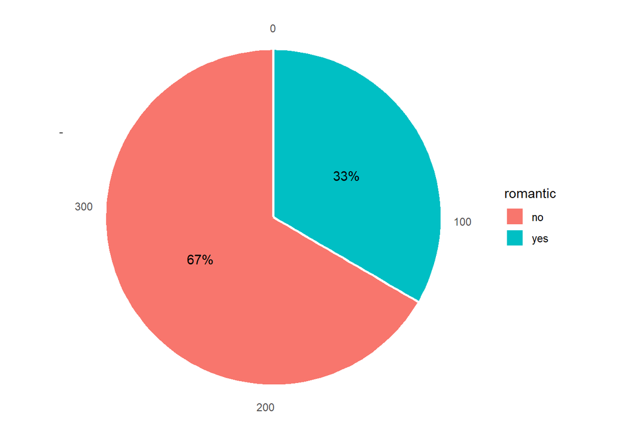

```r
dataset %>% select(romantic) %>%
  count(romantic) %>%
  ggplot(., aes(x="", n, fill = romantic)) +
  geom_bar(width = 1, size = 1, color = "white",stat = "identity") + coord_polar("y", start = 0) +
  geom_text(aes(label = paste0(round((n/395)*100),"%")),
            position = position_stack(vjust = 0.5)) +
  theme_classic() +
  labs(x = NULL, y = NULL) +
  theme(axis.line = element_blank())
```

## Numeric Data Distributions

> DALC

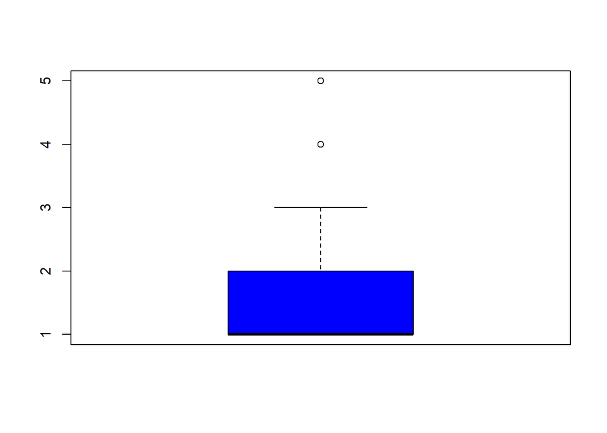

```r
  boxplot(dataset$Dalc, col = "blue", border = "black")
```

> FEDU

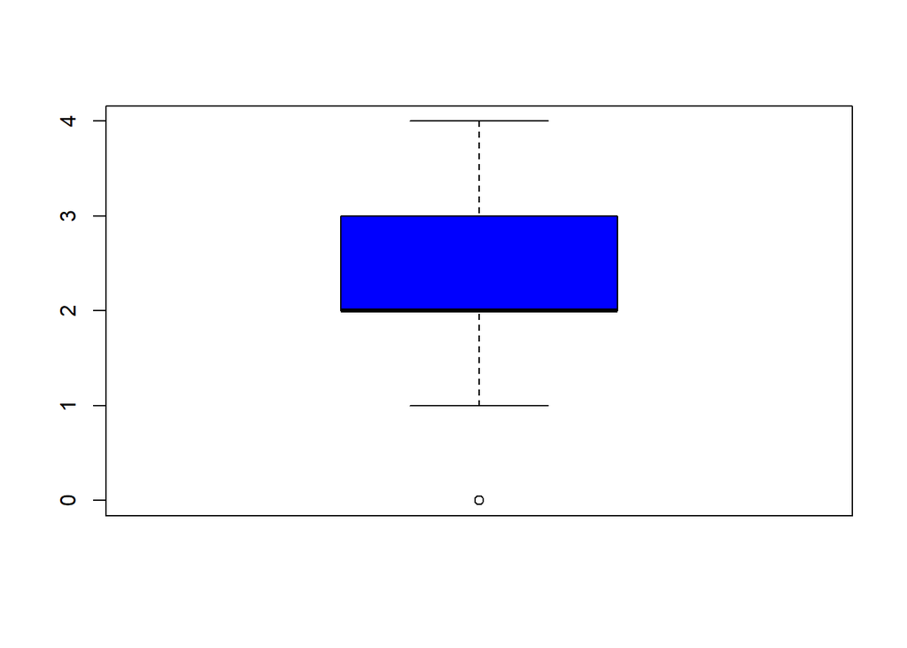

```r
  boxplot(dataset$Fedu, col = "blue", border = "black")
```

> G1

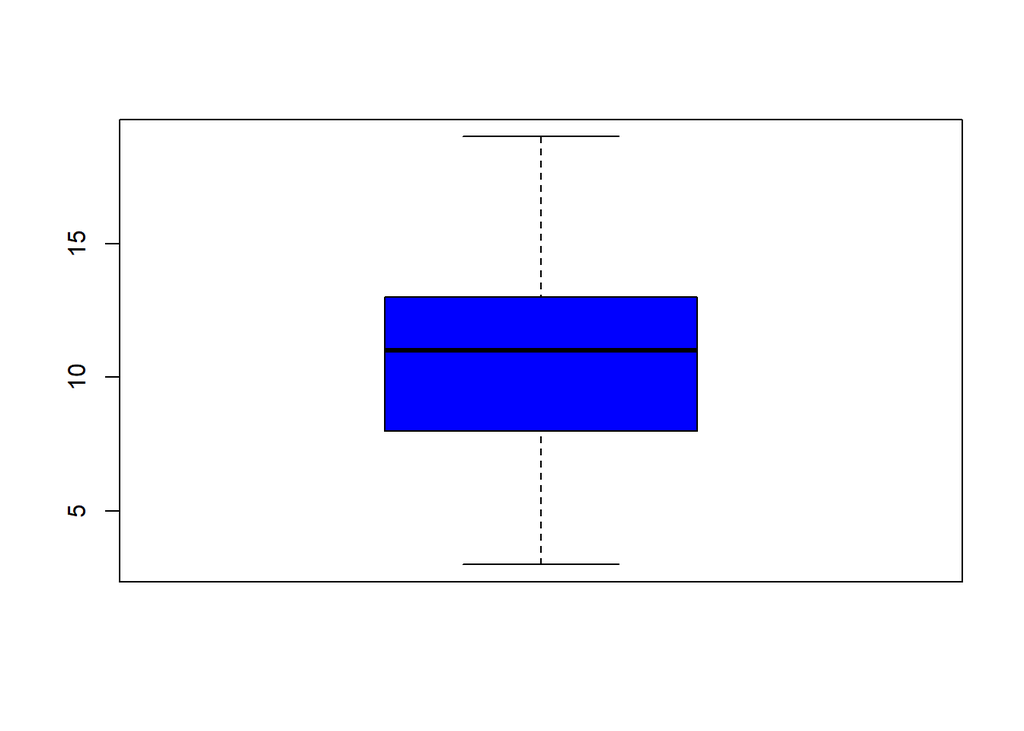

```r
  boxplot(dataset$G1, col = "blue", border = "black")
```

> G2

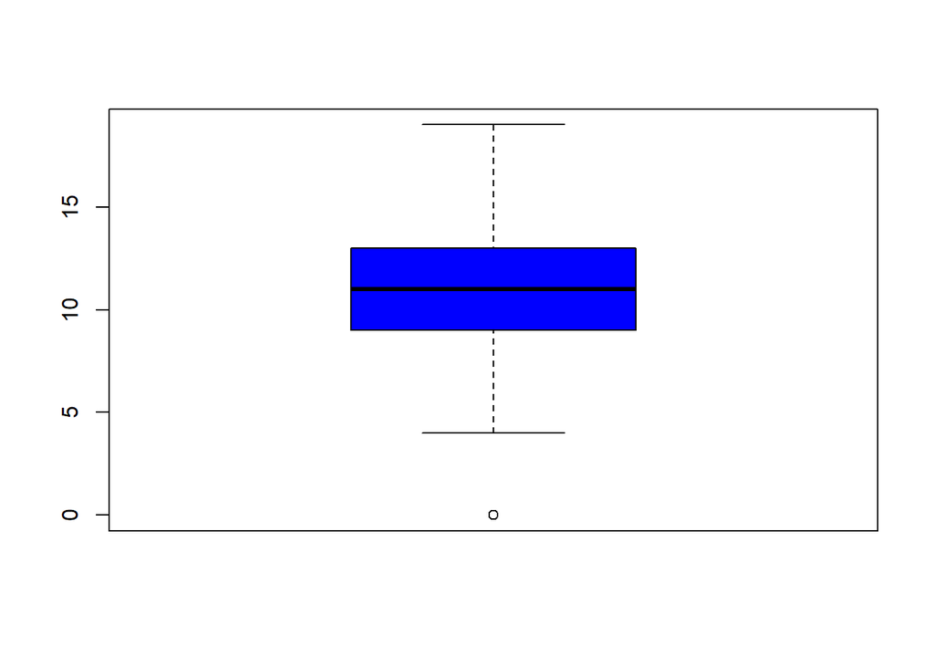

```r
  boxplot(dataset$G2, col = "blue", border = "black")
```

> G3

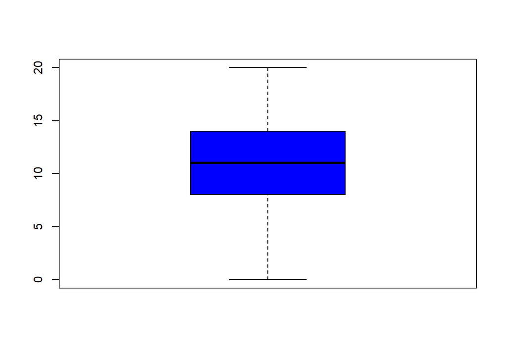

```r
  boxplot(dataset$G3, col = "blue", border = "black")
```

> MEDU

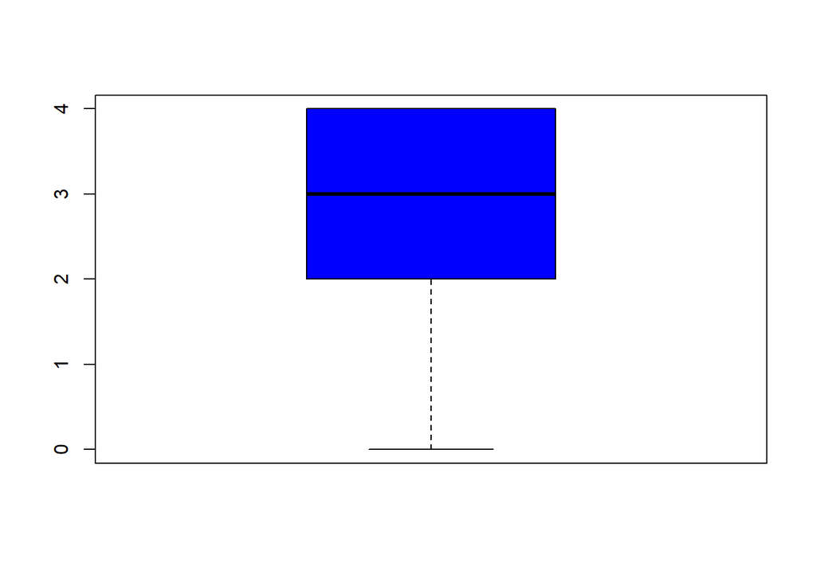

```r
  boxplot(dataset$Medu, col = "blue", border = "black")
```

> WALC

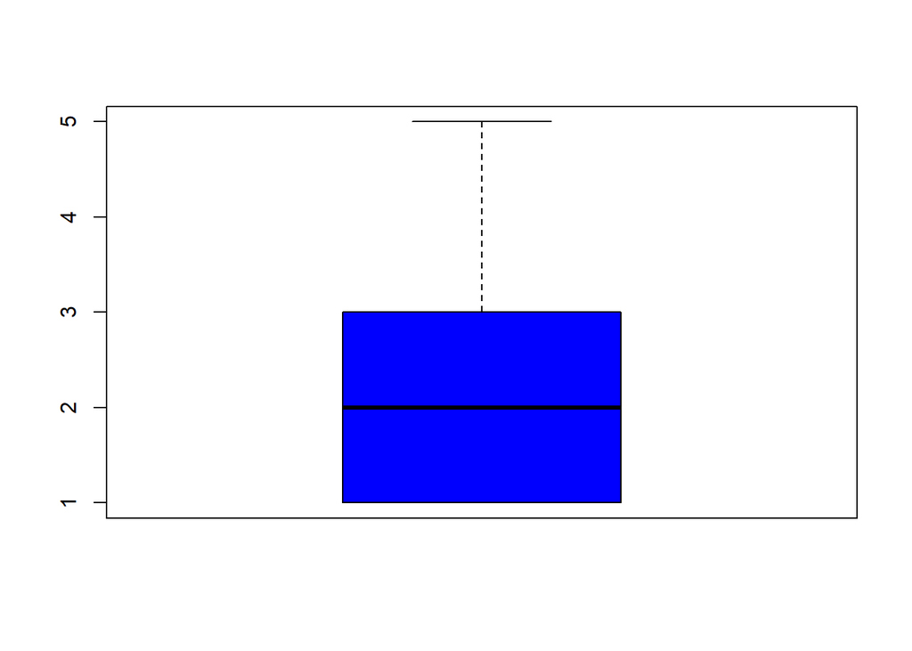

```r
  boxplot(dataset$Walc, col = "blue", border = "black")
```

> ABSENCIES

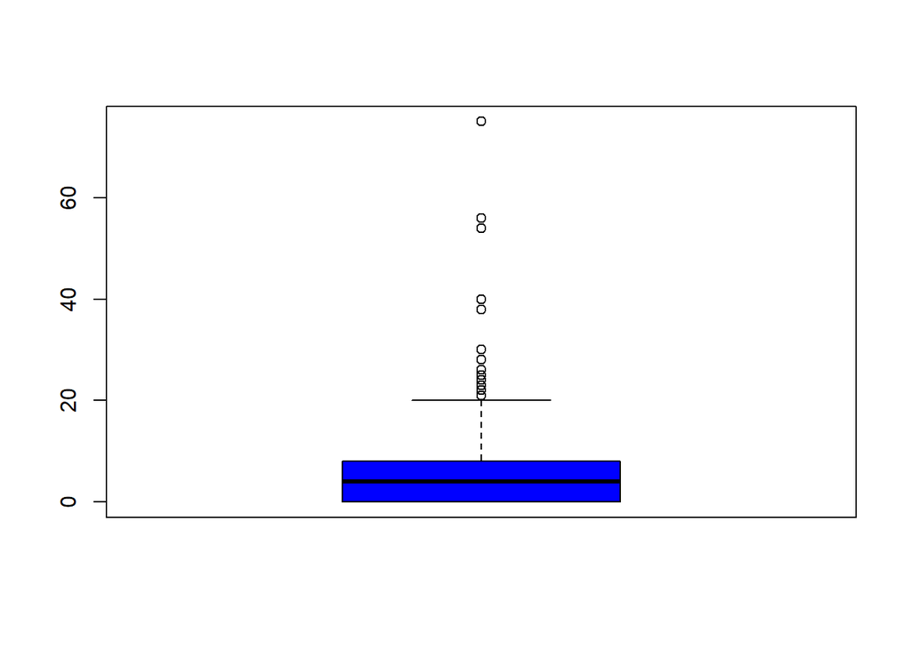

```r
  boxplot(dataset$absences, col = "blue", border = "black")
```

> AGE

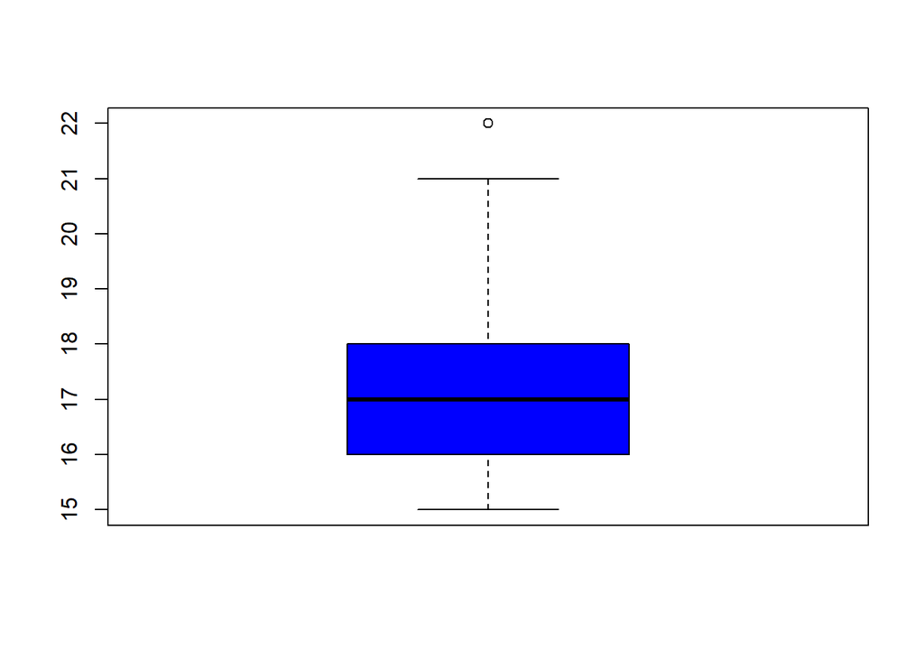

```r
  boxplot(dataset$age, col = "blue", border = "black")
```

> FAILURES

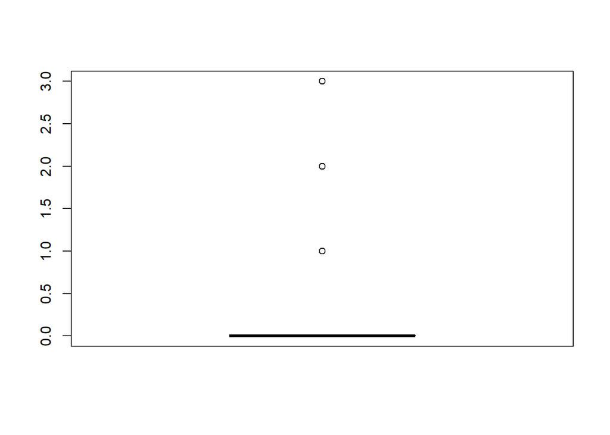

```r
  boxplot(dataset$failures, col = "blue", border = "black")
```

- Pie chart

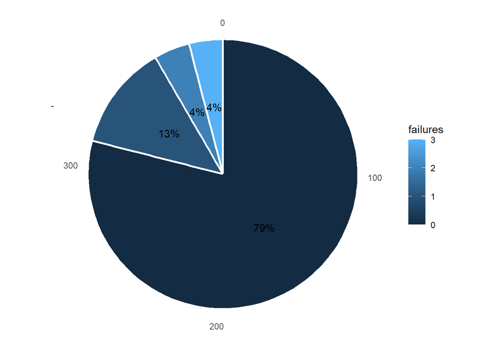

```r
dataset %>% select(failures) %>%
  count(failures) %>%
  ggplot(., aes(x="", n, fill = failures)) +
  geom_bar(width = 1, size = 1, color = "white",stat = "identity") + coord_polar("y", start = 0) +
  geom_text(aes(label = paste0(round((n/395)*100),"%")),
            position = position_stack(vjust = 0.5)) +
  theme_classic() +
  labs(x = NULL, y = NULL) +
  theme(axis.line = element_blank())
```

> FAMREL

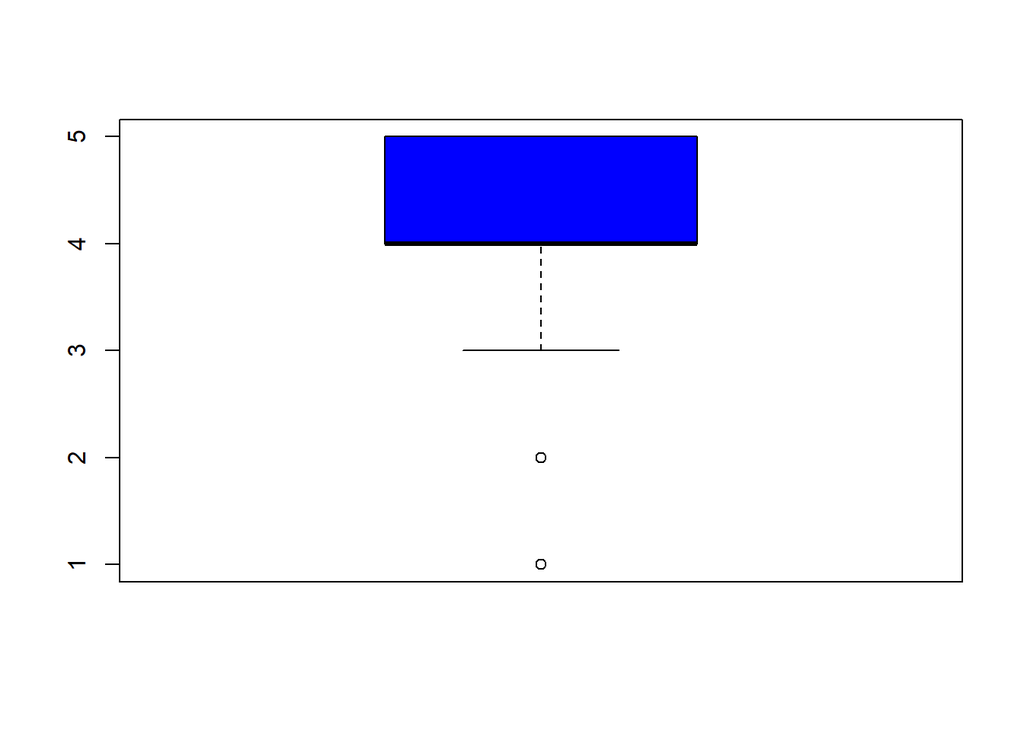

```r
  boxplot(dataset$famrel, col = "blue", border = "black")
```

> FREETIME

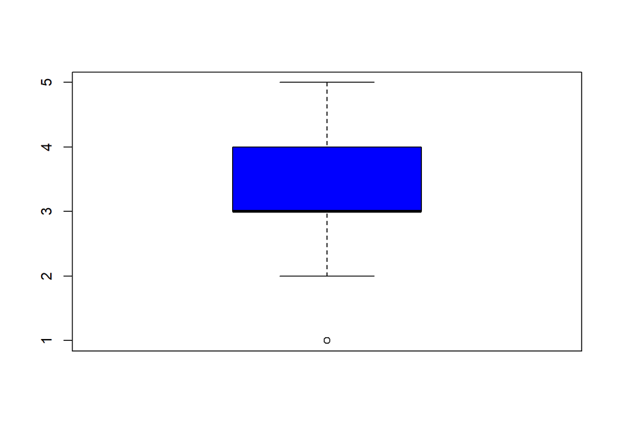

```r
  boxplot(dataset$freetime, col = "blue", border = "black")
```

> GOOUT